Even if the box looks perfectly balanced, we cannot just interpret that the datapoint is evenly distributed. The whiskers provide the information whether the data is positive or negatively skewed. So, first we will look at the box and see if the median is perfectly balanced. If the median is at the lower end of box, we interpret that the data range is positively skewed. If the median lies on the upper end of the box stating that the data is negatively skewed. As the median is perfectly balanced, then we try to interpret information from the whisker seeing that what end the vertical line is stretched.

The boxplot also benefits us with the information on outliers. An outlier is an observation that is numerically distant from the rest of the data.

From the below box plot it’s clear sighted that the Sepal Length for virginica and Sepal Width of Setosa both have outliers (They are the dots that out run the whiskers). While all the other boxplots looked perfectly balanced, we can see that that petal width for both setosa and versicolor are positively skewed as the median lie at the lower end of the boxplot.

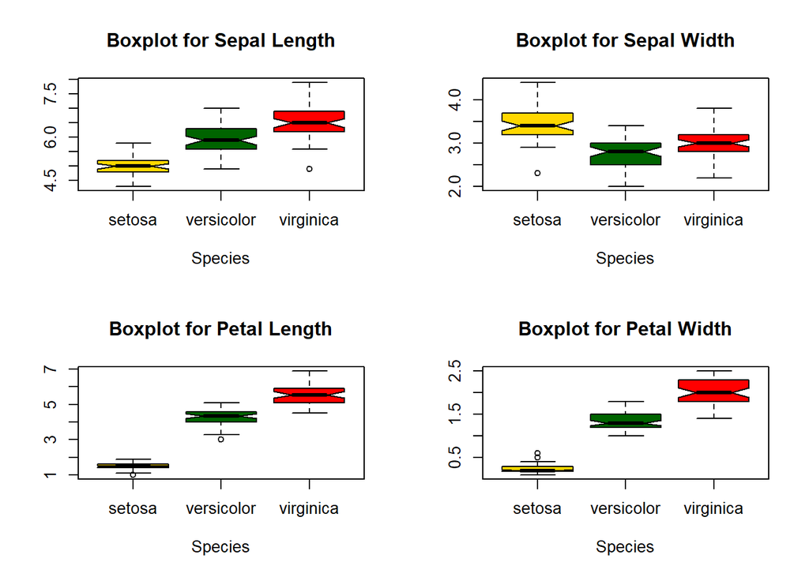

**Density plot:** A density plot is a smoothed version of a histogram. Formally, it is a non-negative function that integrates to 1. The area under the curve in any given interval is an estimate of the probability that that variable will fall into that interval.

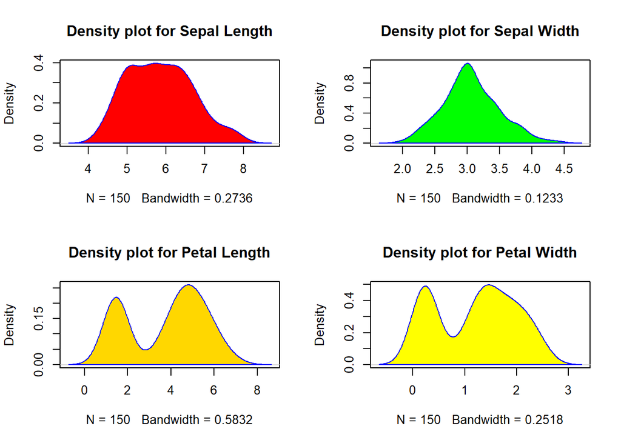

## Unsupervised Learning

**[Jump To Top]**

The idea behind cluster partitioning method like k-means clustering is to define clusters such that the total intra-cluster variation is minimized. Trying different values for k for k-means clustering through trial and error is a tedious process and is not feasible for a large dataset. For instance, we have run k-means for different values of k (3, 4 and 9) after standarizing iris dataset for center and scale as shown below.

The idea behind cluster partitioning method like k-means clustering is to define clusters such that the total intra-cluster variation is minimized. Also, since k-means uses the concept of Euclidean distance, the measure is sensitive to magnitudes and hence should be scaled for all features to weigh in equally. Trying different values for k for k-means clustering through trial and error is a tedious process and is not feasible for a large dataset. For instance, we have run k-means for different values of k (3, 4 and 9) as shown below.

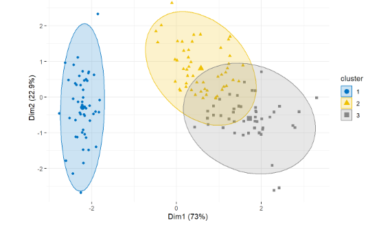

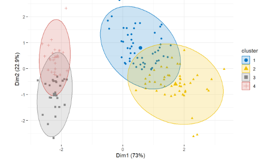

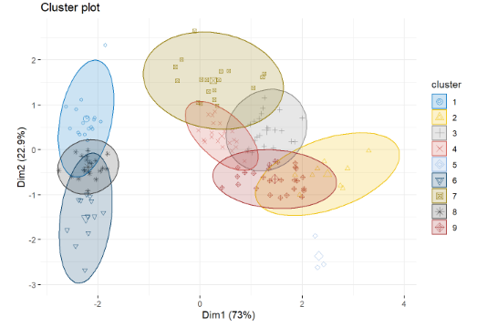

A more logical approach to determine the optimum value of k is the elbow method. Running the scaled iris dataset to generate the elbow graph, we find that the likely values for k could be 3 or 4.

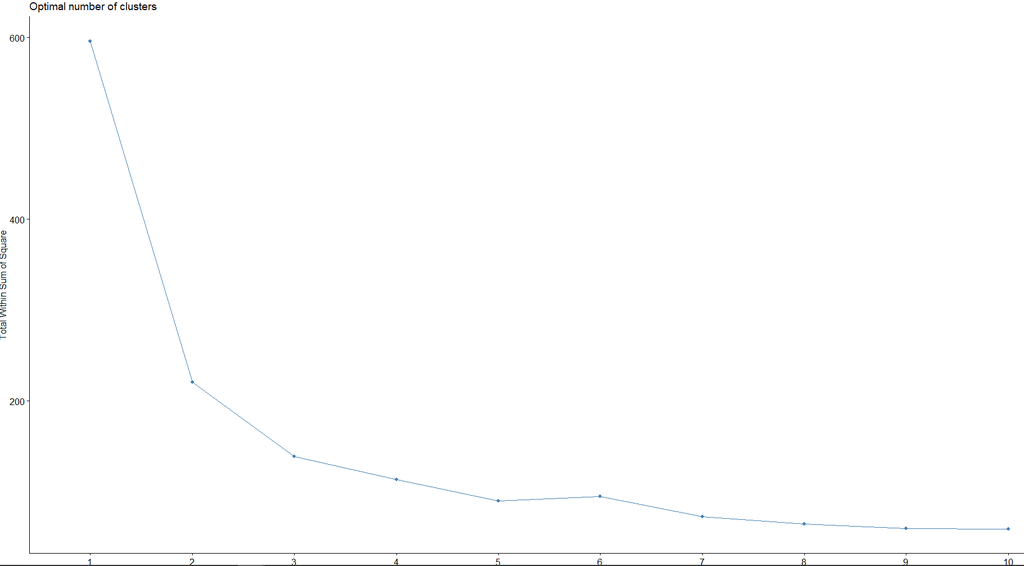

From the graph, the bend indicates that additional clusters beyond the third add little value. Clustering the dataset for both k =3 and 4, we see that k=3 gives better/clearer clusters compared to 4 and also gives a less complex model. So, we consider k=3 for out final output as below.

Also, performing hierarchical clustering for k = 3:

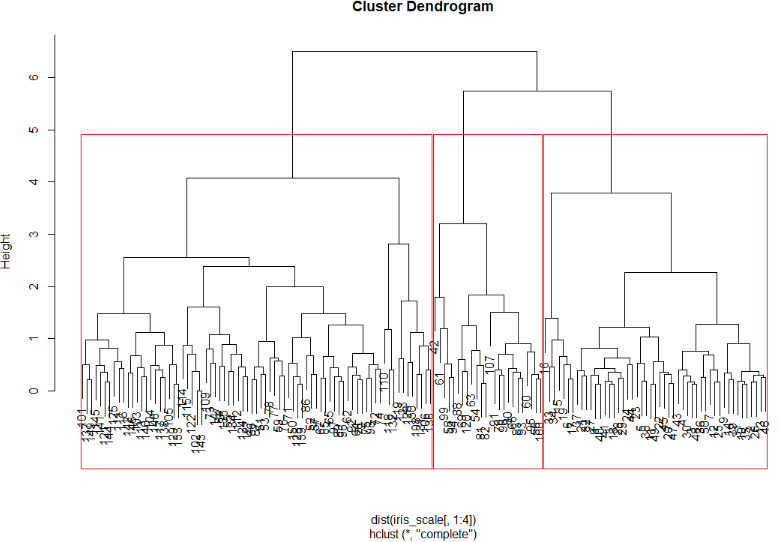

## Supervised Learning

**[Jump To Top]**

KNN classification averages the labels of K nearest neighbour samples to come to a decision. Plotting kNN for different values of k we observe the following percentage accuracy.

KNN classification averages the labels of K nearest neighbour samples to come to a decision. Also, since KNN uses the concept of Euclidean distance, the measure is sensitive to magnitudes and hence should be scaled for all features to weigh in equally. Plotting kNN for different values of k on the scaled iris dataset, we observe as below.

Confusion Matrix for k = 3

```
##             Predicted
## True         setosa versicolor virginica
##   setosa          9          1         0
##   versicolor      0          9         1
##   virginica       0          1         9
```

Number of mismatch values for k = 3

```
## [1] 3
```

Percentage Accuracy for k = 3

```
## [1] 90
```

[output not shown]

Confusion Matrix for k = 5

```
##             Predicted
## True         setosa versicolor virginica
##   setosa         10          0         0
##   versicolor      0         10         0
##   virginica       0          1         9
```

Number of mismatch values for k = 5

```
## [1] 1
```

Percentage Accuracy for k = 5

```
## [1] 96.66667
```

[output not shown]

Confusion Matrix for k = 7

```
##             Predicted
## True         setosa versicolor virginica
##   setosa          9          1         0
##   versicolor      0          9         1
##   virginica       0          1         9
```

Number of mismatch values for k = 7

```
## [1] 3
```

Percentage Accuracy for k = 7

```
## [1] 90
```

[output not shown]

Confusion Matrix for k = 15

```
##             Predicted
## True         setosa versicolor virginica
##   setosa         10          0         0
##   versicolor      0         10         0
##   virginica       0          1         9
```

Number of mismatch values for k = 15

```
## [1] 1
```

Percentage Accuracy for k = 15

```
## [1] 96.66667
```

## References

**[Jump To Top]**

[Density Plot](https://datavizcatalogue.com/methods/density_plot.html)  
[Elbow Plot](https://uc-r.github.io/kmeans_clustering)